# Homework exercise 4

## Time Series

We will be analysing a time series based on the database of food inspections in the city of chicago.  
The data set is in the file “food-inspections.csv”. As it is not originaly a time series, we need to, after loading it, transform de data into a time series.

```r
#libraries required
library(astsa)
library(zoo)
library(ggplot2)
library(forecast)
library(lubridate)
library(readr)

#load database from file
food_inspections <- read_csv("C:/Users/zé/Desktop/programação/R/Final Work/food-inspections.csv")

#get data on the dates and the results of inspections
inspectionDateTable = food_inspections["Inspection Date"]
resultsTable = food_inspections["Results"]

#preprocessing of data
resultsList = unlist(resultsTable)
inspectionDateList = as.Date(unlist(inspectionDateTable)/(24*60*60))
resultsFilterList = ifelse(resultsList == "Pass",1,ifelse(resultsList == "Fail",1,1))
inspectionMatrix = matrix(c(inspectionDateList,resultsFilterList),nrow = length(inspectionDateList),ncol = 2)
inspectionMatrixFilter = inspectionMatrix[inspectionMatrix[,2]==1,]

#aggregate inspections by month and turn it into a time series
inspectionMatrixByMonth = aggregate(inspectionMatrixFilter[,2],by=list(year(as.Date(inspectionMatrixFilter[,1]))*12+month(as.Date(inspectionMatrixFilter[,1]))),FUN=sum)
inspectionTS = ts(inspectionMatrixByMonth[,2],start = c(2010,1),end = c(2019,9),frequency = 12)
```

The series is updated every day, as such the last month is not complete and was removed.  
There is a know break in the data wich occured in the start of 2018 due to policy change.

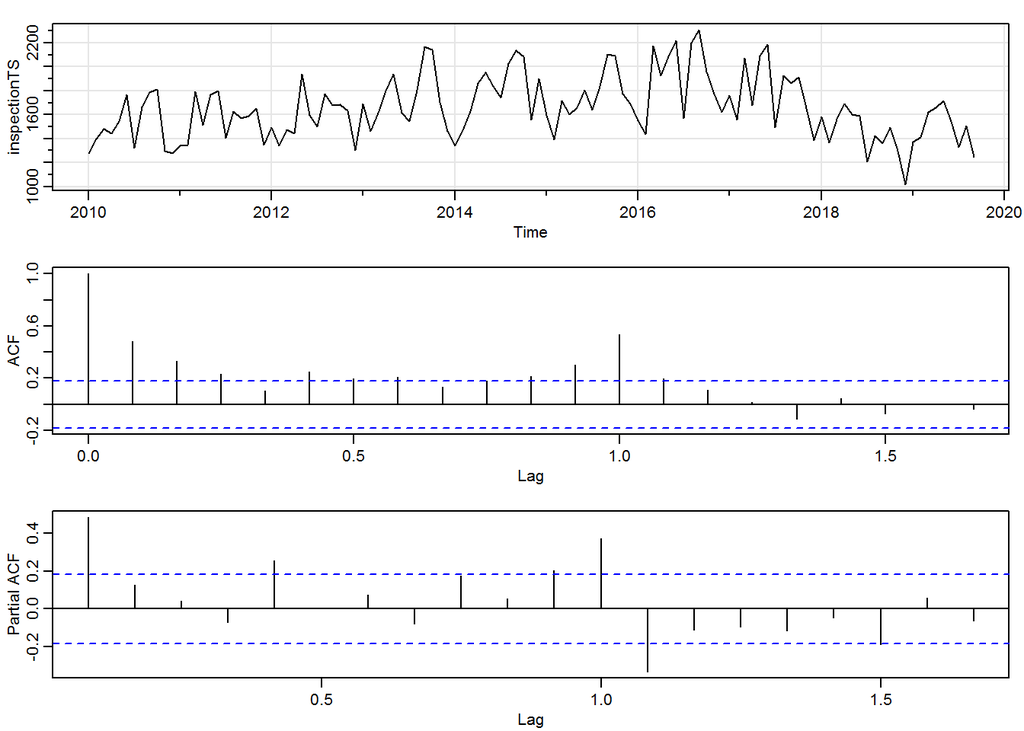

```r
par(mfrow=c(3,1))
tsplot(inspectionTS)
acf(inspectionTS)
pacf(inspectionTS)
```

## Exponential Smothing

The objective of this home work it to use exponential smothing  
to fit and obtain forecasts for the data.

Exponential smoothing designates a set of methods for forecasting that are  
essentially non parametric in the sense that you do not find a model for the  
data and iterate the model to obtain forecasts. Also these methods do not require  
assumptions such as stationarity, Gaussianity, etc. The forecasts are computed from  
the data with weights that decay exponentially.

The basic formula for the predictions is:  
y^T+1|T = αyT + α(1 − α)yT−1 + α(1 − α)^2yT−2 + ⋯

A lot of variations exist, including those with seasonal components and trend components  
For these 2 more parameters must be selected or estimated, gamma and beta, for seasonal and  
trend, respectively.

## Exponential Smothing Aplication

For this work we will use the ets function, wich has both trend and seasonal components.  
It also automaticaly selects the best parameters based on the model.

We will show the time series in black and both the fitted model and predictions in blue.  
The forecast interval will be the last year, and as such said year will not be used to fit the data.

```r
inspectionWindow <- window(inspectionTS, end=c(2018,9))
fit <- ets(inspectionWindow)
summary(fit)
```

```
## ETS(M,A,M)
##
## Call:
##  ets(y = inspectionWindow)
##
##   Smoothing parameters:
##     alpha = 0.1157
##     beta  = 0.0385
##     gamma = 1e-04
##
##   Initial states:
##     l = 1497.9244
##     b = 6.534
##     s = 0.8748 0.9512 1.1117 1.1204 1.0893 0.8997
##            1.0794 1.1026 0.9956 1.0231 0.8523 0.8999
##
##   sigma:  0.0921
##
##      AIC     AICc      BIC
## 1564.436 1571.471 1609.553
##
## Training set error measures:
##                     ME     RMSE      MAE       MPE     MAPE      MASE
## Training set -13.31913 145.8269 122.1602 -1.412066 7.279352 0.6872479
##                   ACF1
## Training set 0.1187889
```

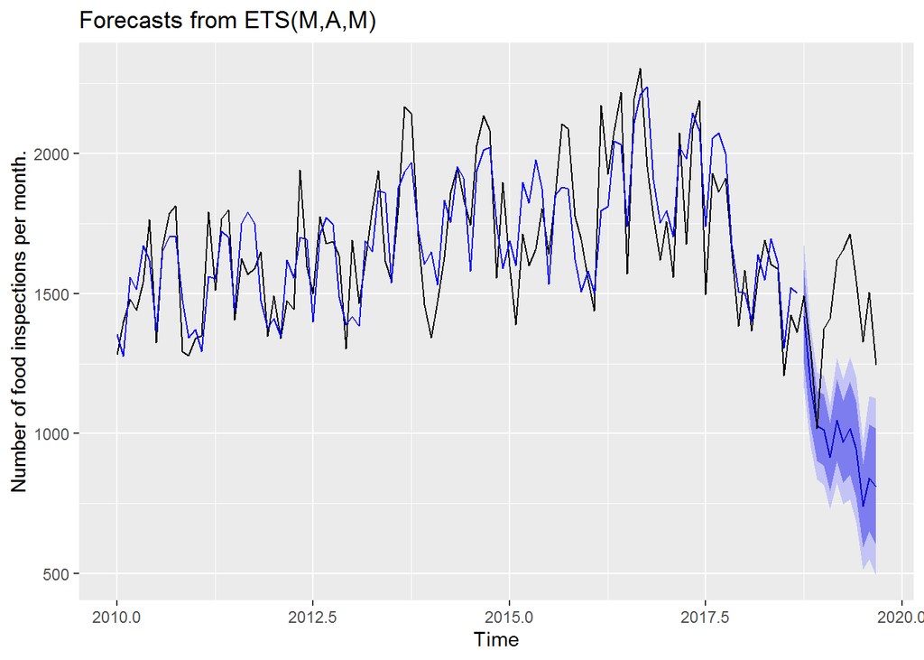

```r
autoplot(forecast(fit,h=12)) +
  autolayer(inspectionTS, series="Real series",color = "black") +
  autolayer(fit$fitted, series="Fitted series",color = "blue") +
ylab("Number of food inspections per month.")
```

As we can see, the fit seems quite good, however the predictions are poor, with most values not even  
laying on the bands of confidence. This may be due to the nature of the problem, as there is the  
previously mentioned change in the data.

Since the forecasts are so poor lets show the acf to see if we managed to use all the information.

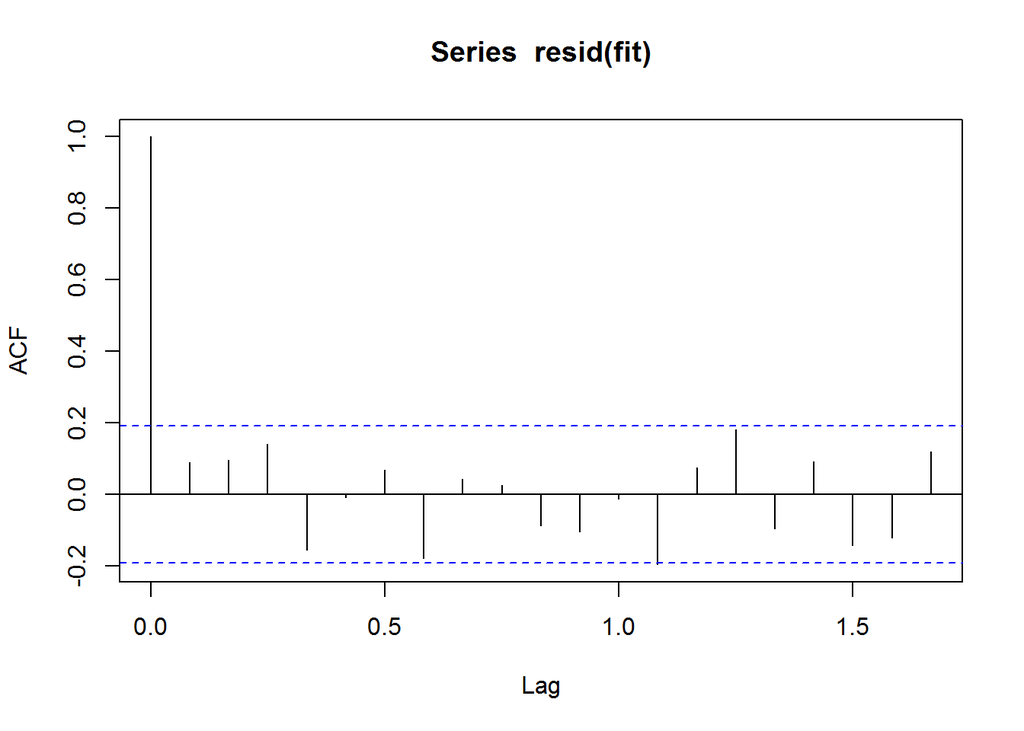

```r
acf(resid(fit))
```

The acf doesn’t have any value outside the confidence bands, so it seems we fitted the data correctly.  
However just to be sure lets do a box test.

```r
Box.test(resid(fit))
```

```
##
##  Box-Pierce test
##
## data:  resid(fit)
## X-squared = 0.81668, df = 1, p-value = 0.3662
```

The box test gives a high p-value, so we conclude the values are not correlated  
and as such we can now conclude that the residuals are white noise.

Given that the data was fitted correctly but the forecasts are poor  
we come to the conclusion that the model is not good for this data.